Manual for assigning metiers to transversal data

Method developed by RCG ISSG on Metier issues

23/04/2025

This document is a practical manual for using the scripts and reference codes created by the ISSG on Métier and transversal variables issues. First, the input data format for transversal data is described in Section 2. The reference lists used in the R-script for métier codes, species codes and area codes are described in Section 3. In Section 4 the metier assignment procedure is described and in Section 5 it is explained how to use the script. Finally, the Section 6 present a workflow diagram. The script and reference tables are updated when needed.

# 1 Background

In 2018 a DCF Métier workshop was held as a subgroup of the RCG’s. Work was done on writing a historical background of the métiers and why they are needed. Participants of the workshop described the national procedures for assigning métiers, and it was clear that different methods and criteria are used for assigning métier codes by the different nations. During the meeting, major issues and possible best practices were discussed, e.g. that the target species assemblage should reflect the fishing intention, and that a métier should be defined for a fishing sequence. Work was started on the reference lists on métiers, species and gears. A general workflow for assigning métiers was developed, and a repository for storing reference lists and scripts was suggested.

A result of the workshop was the consensus regarding the need to standardize and harmonize métier codes and reference tables, as well as the methods to assign métiers to transversal data.

In 2019 the work was followed up by a pan-regional RCG Intersessional Subgroup on Métier Issues that set up a public repository on GitHub for storing reference lists, scripts, métier descriptions and documentation of procedures. The work performed consisted in:

- Suggestion of a system for harmonizing the métier reference lists without overlapping métiers (especially about mesh-size ranges)
- Development of an R-script for assigning métiers to transversal data (tested for the Baltic Sea)
- Development of a template for documenting the method used by countries, including its testing
- Development of a script for making métier descriptions based on data uploaded to the RDB
- Agree on and test a reference list of individual species to be included into species groups
- Test and evaluate the impact of using value vs. weight of landings as metric for assigning target species assemblage groups.

The RCG’s in 2019 recommended that the work was to be followed up and continued in 2020 and 2021, with a stronger focus on an operational métier list and R-script to assign métiers. This includes testing reference tables and R-script and making sure that all relevant métiers and reference codes are included. The reports from the 2018 workshop and the 2019, 2020 and 2021 RCG intersessional work can be found in [the RCG github repository](https://github.com/ices-eg/RCGs/tree/master/Metiers/Reports).

# 2 Input format for transversal data

The script developed for assigning métier codes to transversal data reads a “.csv” file with the input data format described below.

[output not shown]

An example of the input data format can be found on [the github repository.](https://github.com/ices-eg/RCGs/blob/master/Metiers/Metier_data_format_Example_test_input.csv)

# 3 Reference lists

## 3.1 Métier list

The R-script downloads the métier list from [the github repository](https://github.com/ices-eg/RCGs/blob/master/Metiers/Reference_lists/RDB_ISSG_Metier_list.csv). It is also available in excel format.

The métiers reference list at DCF level6 (see “Metier_level6” column), to be considered by the algorithm, has been established by RCG (see “RCG” column): Baltic (BALT), Long Distance Fisheries (LDF), Mediterranean and Black Sea (MBS), North Atlantic (NAtl) and North Sea and Eastern Arctic (NSEA). In some cases, the reference métier codes are dated especially when the reference métier code is allowed only during a fixed time period (see columns “Start_year” and “End-year”). This could be due to legislation.

The column “old_code” is a reference to the corresponding codes used in the previous métier list from the RDB. If they are marked with red in the excel file, the code has changed in the new métier list. The column “Use_by_country_in_RDB” lists the countries that have uploaded data with the considered métiers in the RDB for the 2009-2017 periods and the column “Total_n_trips_RDB_2009t2017” present the sum of the total number of trips with the old codes uploaded to the RDB for 2009 to 2017.

Furthermore, a harmonized metiers reference list at DCF level 7 has been developed to address specific requests from end-users, such as the RCG Large Pelagic fisheries. The reference list can be expanded as necessary. It is stored on Github along with other reference lists in the ‘Reference_lists’ folder. This list provides additional precision regarding the initial métier at DCF level6 referenced in the métier list (e.g., providing more details about the targeted species).

**Procedure for adding new metiers to the list**

If a metier code is missing in the list, it can be requested by sending an email to: Josefine Egekvist (jsv@aqua.dtu.dk) with the new metier code requested, the relevant RCG region (Baltic Sea, North Sea and Eastern Arctic, North Atlantic, Mediterranean, Distant Waters) and the species and fishery should be described. The suggestions will be evaluated at the next meeting within the RCG ISSG on Metier Issues, following the principles: harmonisation, non-overlapping mesh size ranges and not using general gear codes like LX or OT.

These principles are linked with the general rules used initially to develop a harmonized and standardized métier codes reference list. Therefore, when a new code is requested by a MS, it needs to be checked if it follows the set of rules established by the group, and confirmed with the other contact persons, with a short deadline for reply. If it follows the rules, the new code can be accepted, otherwise the reasoning for such proposal should be discussed within the ISSG group, to agree on a final decision.

The set of rules established by the group is detailed hereunder:

- Gear-target species assemblage combinations (métier level 5) follow, as far as possible, table 5 from EU-MAP commission delegated decision (EU 2021/1167).
- Métier level 5 codes are identified by RCG region and should be added in all the RCG regions where they occur by the regions North Sea and Eastern Arctic (NSEA), Baltic Sea (BS), North Atlantic (NAtl), Long distance fisheries (LD) and Mediterranean and Black Sea (MBS).
- Mesh size ranges ensuring no overlapping mesh size ranges by using the standardized mesh size ranges defined initially by RCG region and type of gear (active or passive).
  - The standards mesh size ranges have been defined by considering all the significant mesh size ‘limits’ arising from regulations or common fishing practices. The goal was to develop the smallest range of mesh sizes that covers all the relevant mesh size ‘cuts’ required to meet the regulations or common practices of the RCG region and the gear types considered (active or passive).
- ’_0_0_0’ for gears with no mesh size (e.g., longlines, hand lines, trolling lines),
- ‘>0_0_0’ for unknown mesh size and for the following gears: traps, pots, beach seines and dredges (gears with mesh size but for which no mesh size ranges have been defined).
- Possibility of including relevant selection devices.
- Unknown gear/métier will be coded as “MIS_MIS_0_0_0”, also allowed following codes e.g., “MIS_DEF_0_0_0”, “MIS_CRU_0_0_0” etc. in case the catch composition is known from e.g., sales notes, but the gear is unknown.
- Avoid using FIF (Finfish group) (not calculated from the R-script developed by the ISSG) but métiers codes have been made available with FIF for hooks and longlines, pots and beach seine fisheries for national needs.

## 3.2 Species list

The R-script dowloads the species list from [the github repository](https://github.com/ices-eg/RCGs/blob/master/Metiers/Reference_lists/Metier%20Subgroup%20Species%202020.xlsx).

The species list is a subset from the [ASFIS list of species](http://www.fao.org/fishery/collection/asfis/en) maintained by FAO and include, as far as possible, all the commercial species landed in the RCG fishing areas. FAO species code for the commercial species considered is specified in column A and for each of them some complementary information is available in columns B to G (e.g. “Scientific name”, Taxocode”, “ISSCAAP description”, …). The columns H to T reflect the different ways on grouping the species codes in target assemblage of species groups developed for different purposes: R data package, fishPi EU project, RCM 2007, DWS regulation and what has been done/referenced within countries. In the end, columns U, V and W contain the latest proposal on species groups at three different levels of aggregation. **These aggregations are used by the R-script:**

Grouping 1 in column U aggregate the commercial species into the following target assemblage of species: Crustaceans (CRU), Molluscs (MOL), Finfishes (FIF), Seaweeds (SWD) and Miscellaneous (MIS).

Grouping 2 in column V disaggregate the finfishes category into the following target assemblage of species: Anadromous species (ANA), Catadromous species (CAT), Demersal fish (DEF), Small pelagic fish (SPF), Large pelagic fish (LPF) and Freshwater species (FWS). It disaggregates also the molluscs category into the following target assemblage of species: Cephalopods (CEP) and Other molluscs (MOL).

Grouping 3 - DWS identifies deep water species from the regulation (EC) 2016/2336.

Groupings 2 and 3 constitute the reference basis used by the script and the algorithm to aggregate commercial species into target assemblage of species. Nevertheless and if needed, countries are free to group species differently at national level by including the changes in the R-script.

## 3.3 Area list

The R-script downloads the area list from [the github repository.](https://github.com/ices-eg/RCGs/blob/master/Metiers/Reference_lists/AreaRegionLookup.csv)

Area, SubArea, Division, SubDivision and Unit FAO level [fishing area codes](http://www.fao.org/fishery/area/search/en) are listed in the reference list with their links to the RCG code (same code used in the métier reference list). All the FAO fishing areas possible codification at the different levels are listed except the FAO fishing areas codes at “SubArea level” (e.g. 27.5) or at “Area level” (e.g. 27) which encompass several RCGs. Therefore, for FAO area 27 it is promoted to provide, as a minimum level, FAO area at “Division level” in the input data.

## 3.4 Gear list

The R-script downloads the gearlist from [the github repository.](https://github.com/ices-eg/RCGs/blob/master/Metiers/Reference_lists/Code-ERSGearType-v1.1.xlsx)

ISSCFG FAO [fishing gear classification codes](http://www.fao.org/cwp-on-fishery-statistics/handbook/capture-fisheries-statistics/fishing-gear-classification/en/) are detailed in column A and for each of them: 1) a description of the code is provided in column B and 2) in column C an aggregation by group of fishing gears (e.g. seine nets) is proposed; such aggregation is possibly used in some specific steps of the algorithm.

In column D, a re-coding of some of the declared gear codes is proposed in order to be in line with the gear codification used in the metier list at DCF level5 (e.g. FDV-Free diving => DIV-Diving). Column D is then the column considered by the algorithm and the R-script.

Columns F and G specify if the gear code should be considered regarding the DWS’ specific rules and if yes for which RCGs. “Y” is allocated for gears where DWS metiers are available and therefore DWS’ specific rules apply (e.g. OTB - “Bottom otter trawls”) when “N” is allocated for the other gears.

## 3.5 Selection panels

The last part of the metier codes define the selection panels. When no selection devices are used then “_0_0” codification should be used in the last part of the metier code. For métiers where selection devices are used, following selection panel codes number have been referenced. They have to be filled in the input data format in the “selection” column with, in the second part of the codification, the precision of their mesh size. For the situation when there is both a selection device and escape window (selection panel code number = 4) then the smallest mesh size should be specified in the second part of the codification.

Following selection panel code number have been referenced for the different type of selection panel:

| Code number | Selection panel type |
| --- | --- |
| 0 | No selection device |
| 1 | Selection panel |
| 2 | Grid |
| 3 | T90 |
| 4 | For the situation when there is both a selection device and escape window. |

# 4 Métier assignment procedure

An R-script was developed and tested in 2019 for assigning métiers in the Baltic Sea, which has been further developed in 2020 to cover more areas and details. The R-script is available at https://github.com/ices-eg/RCGs/blob/master/Metiers/Scripts/script_metiers.R and functions are available at https://github.com/ices-eg/RCGs/tree/master/Metiers/Scripts/Functions.

## 4.1 Assigning “metier_level_6”

The script loads the input transversal data in the format described in Section 2, the reference lists described in Section 3, and assigns a RCG code based on the fishing area detailed in the input data (see “area” column) and a target assemblage group of species based on the species landed detailed in the input data (see “FAO_species” column) to each row of the input data. The gear reference list is combined with the input data to define the gear group (gear family) and a new gear code if applicable (“gear_level6” column). Additionally, Deep-Water Species rules are applied and as a consequence the target assemblage is set to “DWS”.

The default fishing sequence, constituting the level at which the metier level 6 will be calculated and assigned, is defined by the following columns: “Country, year, vessel id, vessel length, trip id, haul id, fishing day, area, ices rectangle, gear, mesh size, selection panel & registered target species assemblage”.

Nevertheless, countries are free to define the level of fishing sequence they want to consider nationally. For example, countries could take the decision to not consider fishing “ices rectangle area” when defining the level of fishing sequence at which they want to calculate and assign metier level 6. In that case, they would include only the following columns: “Country, year, vessel id, vessel length, trip id, haul id, fishing day, gear, mesh size, selection panel & registered target species assemblage”. The minimum level of the fishing sequence should be: “Country, year, vessel id, trip ID, RCG (assigned to area), gear and mesh size”.

The principal target assemblage group of species is then calculated by fishing sequence at the level defined before. The principal target assemblage group of species is determined based on the maximum (regarding all the target assemblage group of species landed for the fishing sequence considered) total tonnage of landing calculated by fishing sequence in weight (if all the “measure” column for the fishing sequence considered is filled out with “weight” modality) otherwise in value. A specific algorithm allocates the DWS target species assemblage group as principal target assemblage group of species if deep water species represent more than 8% (according to the Deep Water Regulation (EU) 2016/2336 ) of the total tonnage landed in weight if the combination fishing sequence’ RCG and gear level6 agreed the use of this DWS’ specific rules (specified in the gear list reference table).

Then the combination of the RCG code, the year, the gear, the principal target assemblage group of species calculated before and the mesh size is merged to the métier reference list. The correspondent codification, if available, is therefore assigned to the fishing sequence considered and is detailed in columns “Metier_level_5” and “Metier_level_6”. In the case there is no correspondence with the métier reference list, then ”MIS_MIS” and “MIS_MIS_0_0_0” codes are assigned to “Metier_level_5” and “Metier_level_6” columns respectively in the fishing sequence.

## 4.2 National corrections

The R-script has been developed in order to improve normalization between countries to assign métier level6 to their national transversal data. It meets a need identified during the 2018 DCF métier workshop which emphasizes the necessity to standardize and harmonize the methods to assign métiers to transversal data between countries. It seeks to be used as the core method shared between countries to assign métiers to fishing sequences. Nevertheless, countries could have some national specificities which have to be taken into account when assigning métiers. These national corrections could be added into the R-script (for example: corrections of a species grouping if the species are fished within another métier nationally or corrections of gear codes (e.g. grouping or recoding imprecise gear codes (GN, TB)). Another example discussed for national correction is the fishery for Thachurus trachurus (horse mackerel), which is caught as a pelagic species in PS fishery and as demersal species in OTB fishery. In this case, it is suggested that the species will be grouped into the relevant target assemblage group based on the gear code used as a national correction.

Countries are encouraged to upload their script with national corrections to GitHub under https://github.com/ices-eg/RCGs/tree/master/Metiers/Documentation_by_MS along with the documentation of the methods. Other countries could then use similar methods in their scripts if relevant, e.g. for defining selection panels, mixed target assemblage groups etc. The lines with national corrections should be marked with #Country code. The scripts uploaded don’t need to be final, they can be updated as they improve.

## 4.3 Function assigning métiers to fishing sequences

A function has been developed to try to allocate a metier Level5 and Level6 to fishing sequences for which the first metier assignment script does not allocate any metier and therefore it was coded as “MIS_MIS” and “MIS_MIS_0_0_0”.

The algorithm considers different hierarchical steps with, at each step, an incremental hierarchy of selection criteria from the most precise combination to a more generic. A default list of criteria to be considered by the algorithm are proposed in the R-script and detailed here under but they could be adapted nationally, if needed, like the fishing sequence definition (see here above).

The two first steps consider the “vessel pattern” i.e. the métiers calculated for the vessel by the first step of the algorithm which could enable the metier calculation when the gear is missing, inaccurate/imprecise (e.g. TB, GN) or wrong (not in accordance with the target species group calculated, e.g. typing error, reporting error, …). Step 2 enables also the metier calculation for fishing sequences without any catches (no catches’ fishing sequences) or fishing sequences for which FAO species are unallocated (e.g. input error).

The two following steps (steps 3 and 4) consider groups of vessels aggregated on the basis of their vessel length class and fleet register gear. They apply especially for vessels for which the precedent steps do not allocate any metiers for each of their fishing sequences (e.g. vessels for which all their fishing sequences are not informed regarding the fishing gear used). In these cases, the metiers allocated for their same group of vessels are considered.

**1st step** consider the vessel’ pattern and the target species group calculated for the fishing sequence considered. Area is considered in the first steps. Temporal aggregation ranges from month to year :

1.1) Assign metier to same vessel, **month, area** and species group

1.2) Assign metier to same vessel, **quarter, area** and species group

1.3) Assign metier to same vessel, **year, area** and species group

1.4) Assign metier to same vessel, **month** and species group

1.5) Assign metier to same vessel, **quarter** and species group

1.6) Assign metier to same vessel, **year** and species group

For each of these steps (1.1 to 1.6), a specific algorithm is applied if more than one Metier Level6 corresponds to the level considered. In this case, the one with the highest number of sequences in the same gear group is considered and if there is none the one with the highest number of sequences without considering the gear group is considered.

**2nd step** consider the remaining non allocated fishing sequences for which the 1st step does not find a metier. This step continues to consider the vessel’ pattern but here in combination with the gear level6 or the gear group declared of the fishing sequence considered. This step should be especially useful for no catches’ fishing sequences or fishing sequences for which FAO species are unallocated (e.g. input error). As before, area is considered in the first steps and temporal aggregation ranges from month to year:

2.1) Assign metier to same vessel, **month, area and gear**

2.2) Assign metier to same vessel, **quarter, area and gear**

2.3) Assign metier to same vessel, **year, area and gear**

2.4) Assign metier to same vessel, **month and gear**

2.5) Assign metier to same vessel, **quarter and gear**

2.6) Assign metier to same vessel, **year and gear**

2.7) Assign metier to same vessel, **month, area and gear group**

2.8) Assign metier to same vessel, **quarter, area and gear group**

2.9) Assign metier to same vessel, **year, area and gear group**

2.10) Assign metier to same vessel, **month and gear group**

2.11) Assign metier to same vessel, **quarter and gear group**

2.12) Assign metier to same vessel, **year and gear group**

For each of these steps (2.1 to 2.12), a specific algorithm is applied if more than one Metier Level6 corresponds to the level considered. In this case, the one with the highest number of sequences is considered.

**3rd step** applies to remaining non allocated fishing sequences for which “vessel pattern” (steps 1 & 2) do not allow to allocate a metier. This step considers groups of vessels aggregated on the basis of their vessel length class and fleet register gear. It also considers the target species group calculated for the fishing sequence considered. As before, area is considered in the first steps and temporal aggregation ranges from month to year:

3.1) Assign metiers to same **month, vessel length group, fleet register gear, area and species group**

3.2) Assign metiers to same **month, fleet register gear, area and species group**

3.3) Assign metiers to same **quarter, vessel length group, fleet register gear, area and species group**

3.4) Assign metiers to same **quarter, fleet register gear, area and species group**

3.5) Assign metiers to same **year, vessel length group, fleet register gear, area and species group**

3.6) Assign metiers to same **year, fleet register gear, area and species group**

3.7) Assign metiers to same **month, vessel length group, fleet register gear and species group**

3.8) Assign metiers to same **month, fleet register gear and species group**

3.9) Assign metiers to same **quarter, vessel length group, fleet register gear and species group**

3.10) Assign metiers to same **quarter, fleet register gear and species group**

3.11) Assign metiers to same **year, vessel length group, fleet register gear and species group**

3.12) Assign metiers to same **year, fleet register gear and species group**

For each of these steps (3.1 to 3.12), a specific algorithm is applied if more than one Metier Level6 corresponds to the level considered. In this case, the one with the highest number of sequences in the same gear group is considered and if there is none the one with the highest number of sequences without considering the gear group is considered.

**4th step** considers the remaining non allocated fishing sequences for which the first three steps does not find a metier. This step continues to consider groups of vessels aggregated on the basis of their vessel length class and fleet register gear but here in combination with the gear level6 or the gear group declared of the fishing sequence considered. This step should be also especially useful for no catches’ fishing sequences or fishing sequences for which FAO species are unallocated (e.g. input error). As before, area is considered in the first steps and temporal aggregation ranges from month to year:

4.1) Assign metiers to same **month, vessel length group, fleet register gear, area and gear**

4.2) Assign metiers to same **month, fleet register gear, area and gear**

4.3) Assign metiers to same **quarter, vessel length group, fleet register gear, area and gear**

4.4) Assign metiers to same **quarter, fleet register gear, area and gear**

4.5) Assign metiers to same **year, vessel length group, fleet register gear, area and gear**

4.6) Assign metiers to same **year, fleet register gear, area and gear**

4.7) Assign metiers to same **month, vessel length group, fleet register gear and gear**

4.8) Assign metiers to same **month, fleet register gear and gear**

4.9) Assign metiers to same **quarter, vessel length group, fleet register gear and gear**

4.10) Assign metiers to same **quarter, fleet register gear and gear**

4.11) Assign metiers to same **year, vessel length group, fleet register gear and gear**

4.12) Assign metiers to same **year, fleet register gear and gear**

4.13) Assign metiers to same **month, vessel length group, fleet register gear, area and gear group**

4.14) Assign metiers to same **month, fleet register gear, area and gear group**

4.15) Assign metiers to same **quarter, vessel length group, fleet register gear, area and gear group**

4.16) Assign metiers to same **quarter, fleet register gear, area and gear group**

4.17) Assign metiers to same **year, vessel length group, fleet register gear, area and gear group**

4.18) Assign metiers to same **year, fleet register gear, area and gear group**

4.19) Assign metiers to same **month, vessel length group, fleet register gear and gear group**

4.20) Assign metiers to same **month, fleet register gear and gear group**

4.21) Assign metiers to same **quarter, vessel length group, fleet register gear and gear group**

4.22) Assign metiers to same **quarter, fleet register gear and gear group**

4.23) Assign metiers to same **year, vessel length group, fleet register gear and gear group**

4.24) Assign metiers to same **year, fleet register gear and gear group**

For each of these steps (4.1 to 4.24), a specific algorithm is applied if more than one Metier Level6 corresponds to the level considered. In this case, the one with the highest number of sequences is considered.

## 4.4 Function looking at dominant/main metiers used by vessel

A function in the métier allocation R-script enables to refine the métiers firstly assigned by the general algorithm to take into account the dominant/main metiers used by vessels, correcting for accidental catches of non-targeted species in a haul. This step contributes in particular to limit the multiplication of métiers calculated (focus on the year*vessel’ main metiers avoiding “rare” métiers firstly assigned by the general algorithm).

The three following steps are considered to define the fishing sequences for which a “rare” metier DCF level5 has been assigned. The other fishing sequences compile the dominant/main metiers DCF level5 of the vessels which are potentially used to replace the “rare” metiers firstly assigned.

5.1) **Calculate by “year*vessel” the number and % of fishing sequences by “metier DCF level5” calculated** (based on the fishing sequences completed before i.e. for which a “metier level6” then “metier level5” has been calculated in the first steps of the script including the previous steps which are trying to allocate a metier to firstly non allocated fishing sequences).

5.2) **Fishing sequences** for which the “metier level5” associated has been calculated for less than rare **threshold** % (define before in the R-script – e.g. 5-10%) of the fishing sequences completed, are reset (reset “metier level5” to Null). Such “metier level5” are considered as “rare” metier for the “year*vessel” considered and have to be faced with the principal practices of the “year*vessel”.

5.3) Other **“metier level5”** calculated for more than the **rare threshold** % (e.g. 5-10%) of the fishing sequences are kept. They constitute the dominant/main metiers level5 used by the “year*vessel” on which the following script will be based on.

For the fishing sequences reset (“rare” metier first attributed), then the following steps will compare “target species group” calculated with the “target species groups” of the dominant metiers of the “year*vessel” pattern following the order described hereunder.

5.4) Assign metier **Level5** to same vessel, **month, area** and species group

5.5) Assign metier **Level5** to same vessel, **quarter, area** and species group

5.6) Assign metier **Level5** to same vessel, **year, area** and species group

5.7) Assign metier **Level5** to same vessel, **month** and species group

5.8) Assign metier **Level5** to same vessel, **quarter** and species group

5.9) Assign metier **Level5** to same vessel, **year** and species group

For each of these steps (5.4 to 5.9), a specific algorithm is applied if more than one metier level5 corresponds to the level considered. In this case, the one with the highest number of sequences in the same gear group is considered and if there is none the one with the highest number of sequences without considering the gear group is considered.

Then for the fishing sequences reset (“rare” metier first attributed) for which the “target species group” does not match with the “target species groups” of at least one of the dominant “metiers level5” of the “year*vessel” considered (previous steps 5.4 to 5.9) then the following steps will compare the gear declared of the fishing sequence considered with the gears and gear groups of the dominant “metiers level5” of the “year*vessel” considered following the order described hereunder.

5.10) Assign metier **Level5** to same vessel, **month, area and gear**

5.11) Assign metier **Level5** to same vessel, **quarter, area and gear**

5.12) Assign metier **Level5** to same vessel, **year, area and gear**

5.13) Assign metier **Level5** to same vessel, **month and gear**

5.14) Assign metier **Level5** to same vessel, **quarter and gear**

5.15) Assign metier **Level5** to same vessel, **year and gear**

5.16) Assign metier **Level5** to same vessel, **month, area and gear group**

5.17) Assign metier **Level5** to same vessel, **quarter, area and gear group**

5.18) Assign metier **Level5** to same vessel, **year, area and gear group**

5.19) Assign metier **Level5** to same vessel, **month and gear group**

5.20) Assign metier **Level5** to same vessel, **quarter and gear group**

5.21) Assign metier **Level5** to same vessel, **year and gear group**

For each of these steps (5.10 to 5.21), a specific algorithm is applied if more than one metier level5 corresponds to the level considered. In this case, the one with the highest number of sequences is considered. Finally and in a last step 5.22), the “rare” metier firstly attributed is confirmed/validated and allocated to the reset fishing sequence considered for the ones not completed at this stage.

It is then up to the end-user to keep the potential new metier DCF level5 (steps 5.1 to 5.21) attributed and to assign therefore a reviewed DCF level6 métier with the following mesh size ranges “>0_0_0” or “0_0_0” depending of the gear considered to the fishing sequence considered. The mesh size ranges could be then precised with the following function.

## 4.5 Function assigning a mesh size ranges (metier DCF level6)

This function assigns the best matched metier level 6 for metier level 5 assigned from the vessel pattern by the previous function. The following steps will compare the metiers level 5 found in the pattern with initially assigned metiers level 5 (excluding the rare ones) which have a metier level 6 assigned, following the order described below:

6.1) Assign mesh size ranges (& metier level6 associated) to same vessel, **month, area and metier level5 from the pattern**

6.2) Assign mesh size ranges (& metier level6 associated) to same vessel, **quarter, area and metier level5 from the pattern**

6.3) Assign mesh size ranges (& metier level6 associated) to same vessel, **year, area and metier level5 from the pattern**

6.4) Assign mesh size ranges (& metier level6 associated) to same vessel, **month and metier level5 from the pattern**

6.5) Assign mesh size ranges (& metier level6 associated) to same vessel, **quarter and metier level5 from the pattern**

6.6) Assign mesh size ranges (& metier level6 associated) to same vessel, **year and metier level5 from the pattern**

For each of these steps (6.1 to 6.6), a specific algorithm is applied if more than one mesh size ranges (& metier level6 associated) correspond to metier level5 from the pattern and the level considered. In this case, the one with the highest number of sequences is considered.

**At this stage of data processing two new columns are added: “metier_level_5_new” and “metier_level_6_new”. They are filled with metier codes initially assigned, with “MIS…” codes replaced with the best match, and finally rare metiers replaced with the ones found in the pattern.**

## 4.6 Function assigning metier level 6 with more precise mesh size ranges

This function tries to complete mesh size ranges for fishing sequences where the mesh size declared was not compatible with the metier DCF level5 considered (e.g. typing error or reporting error) or not available (e.g. mesh size not declared) and also for the fishing sequence revised after applying the “rare” function (see above). For that, the vessel pattern of the vessel is considered to allocate to the fishing sequence the most frequent mesh size ranges observed for the same metier DCF level5. As before, a stepwise procedure is applied with, at each step, an incremental hierarchy of selection criteria from the most precise combination to a more generic. The following steps are tested otherwise the “>0_0_0” mesh size range is retained:

7.1) Assign mesh size ranges (& metier level6 associated) to same vessel, **month, area and metier level5 (new)**

7.2) Assign mesh size ranges (& metier level6 associated) to same vessel, **quarter, area and metier level5 (new)**

7.3) Assign mesh size ranges (& metier level6 associated) to same vessel, **year, area and metier level5 (new)**

7.4) Assign mesh size ranges (& metier level6 associated) to same vessel, **month and metier level5 (new)**

7.5) Assign mesh size ranges (& metier level6 associated) to same vessel, **quarter and metier level5 (new)**

7.6) Assign mesh size ranges (& metier level6 associated) to same vessel, **year and metier level5 (new)**

For each of these steps (7.1 to 7.6), a specific algorithm is applied if more than one mesh size ranges (& metier level6 associated) correspond to metier level5 and the level considered. In this case, the one with the highest number of sequences is considered.

## 4.7 Results

The resulting file, which is the input data with algorithm’ outputs (i.e. outputs resulting from the implementation of the algorithm) added (e.g. “Metier_level6”) is saved as a “.csv” file into a path which has to be specified. The results are also summed up and saved in an excel file that gives an overview of the métiers allocated.

# 5 Description of metier assignment script workflow

This documents explains the metier assignment workflow implemented in the R script developed during work of RCG ISSG Metier issues. Every step of the data analysis is described below.

## 5.1 Including libraries

```r
library(stringr)
library(data.table)
library(openxlsx)
library(purrr)
library(lubridate)
```

## 5.2 Importing functions

Import all functions from files located in the *Functions* folder.

```r
for(f in list.files(path="./Functions", full.names = T)){
  source(f)
}
rm(f)
```

## 5.3 Loading input data

Input data should follow the format developed during the work of ISSG and should be saved as csv file.

```r
data.file <- "data_input_example.csv"
input.data <- loadInputData(data.file)
rm(data.file)
```

| Country | year | vessel_id | vessel_length | trip_id | haul_id | fishing_day | area | ices_rectangle | gear | gear_FR | mesh | selection | registered_target_assemblage | FAO_species | metier_level_6 | measure | KG | EUR |
| --- | --- | --- | --- | --- | --- | --- | --- | --- | --- | --- | --- | --- | --- | --- | --- | --- | --- | --- |
| POL | 2018 | AAA-1 | 15 | POLAAA1201806100325 | NA | 10-06-2018 | 27.2.a | NA | OTB | OTB | 100 | NA | NA | HXC | NA | weight | 400 | 2500 |
| POL | 2018 | AAA-1 | 15 | POLAAA1201806100325 | NA | 10-06-2018 | 27.2.a | NA | OTB | OTB | 100 | NA | NA | SHO | NA | weight | 200 | 400 |
| POL | 2018 | AAA-1 | 15 | POLAAA1201806100325 | NA | 10-06-2018 | 27.2.a | NA | OTB | OTB | 100 | NA | NA | HER | NA | weight | 500 | 475 |
| POL | 2018 | AAA-1 | 15 | POLAAA1201806100325 | NA | 10-06-2018 | 27.2.a | NA | OTB | OTB | 100 | NA | NA | SPR | NA | weight | 1800 | 1710 |
| POL | 2018 | AAA-1 | 15 | POLAAA1201807011230 | NA | 02-07-2018 | 27.3.d.25 | 37G5 | OTB | OTB | 110 | NA | NA | COD | NA | weight | 500 | NA |

## 5.4 Input data format validation

The *validateInputDataFormat* function checks if all columns defined in the data format are present in the input data set and if they are of a correct data type. If any of the columns defined in the data format are not present, the function fill stop executing and return an error. If any column has different type than expected then the function will return a warning. If there are additional columns not included in the data format, the function will return a warning. If any of the columns are factors the function will return an error.

```r
validateInputDataFormat(input.data)
```

```
## [1] "Column Country: validation passed."
## [1] "Column year: validation passed."
## [1] "Column vessel_id: validation passed."
## [1] "Column vessel_length: validation passed."
## [1] "Column trip_id: validation passed."
## [1] "Column fishing_day: validation passed."
## [1] "Column area: validation passed."
## [1] "Column ices_rectangle: validation passed."
## [1] "Column gear: validation passed."
## [1] "Column gear_FR: validation passed."
## [1] "Column mesh: validation passed."
## [1] "Column selection: validation passed."
## [1] "Column registered_target_assemblage: validation passed."
## [1] "Column FAO_species: validation passed."
## [1] "Column measure: validation passed."
## [1] "Column KG: validation passed."
## [1] "Column EUR: validation passed."
```

```
## [1] TRUE
```

## 5.5 Loading reference lists

The following code will import reference lists from the GitHub repository.

- areas,
- species,
- metiers,
- gear.

```r
url <- "https://github.com/ices-eg/RCGs/raw/master/Metiers/Reference_lists/AreaRegionLookup.csv"
area.list <- loadAreaList(url)
url <- "https://github.com/ices-eg/RCGs/raw/master/Metiers/Reference_lists/Metier%20Subgroup%20Species.xlsx"
species.list <- loadSpeciesList(url)
url <- "https://github.com/ices-eg/RCGs/raw/master/Metiers/Reference_lists/RDB_ISSG_Metier_list.csv"
metier.list <- loadMetierList(url)
url <- "https://github.com/ices-eg/RCGs/raw/master/Metiers/Reference_lists/Code-ERSGearType-v1.1.xlsx"
gear.list <- loadGearList(url)
assemblage.list <- unique(c(species.list$species_group, species.list$dws_group))
assemblage.list <- assemblage.list[!is.na(assemblage.list)]
rm(url)
```

## 5.6 Input data codes validation

The *validateInputDataCodes* function validates the codes in the columns: area, gear, gearFR, selection, registered_target_assemblage, FAO_species, measure. If any of the above mentioned columns contains invalid etries then the function gives a warning.

```r
validateInputDataCodes(input.data, gear.list, area.list, species.list)
```

```
## [1] TRUE
```

## 5.7 Input data preparation

**Basic conversions/recodings**

```r
input.data[,EUR:=as.numeric(EUR)]
input.data[,KG:=as.numeric(KG)]
input.data[,c("selection_type","selection_mesh"):=data.table(str_split_fixed(selection,"_",2))]
input.data[,selection_type:=ifelse(selection_type=="",NA,selection_type)]
input.data[,selection_mesh:=ifelse(selection_mesh=="",NA,selection_mesh)]
```

**Assign RCG names to the input data**

```r
input.data <- merge(input.data, area.list, all.x = T, by = "area")
```

**Assign species categories to the input data**

```r
input.data <- merge(input.data, species.list, all.x = T, by = "FAO_species")
```

**Assign gear group and recoded gear name to the input data**

```r
input.data<-merge(input.data, gear.list, all.x = T, by.x = "gear", by.y = "gear_code")
```

| gear | FAO_species | area | Country | year | vessel_id | vessel_length | trip_id | haul_id | fishing_day | ices_rectangle | gear_FR | mesh | selection | registered_target_assemblage | metier_level_6 | measure | KG | EUR | selection_type | selection_mesh | RCG | species_group | dws_group | gear_group | gear_level6 | DWS_for_RCG |
| --- | --- | --- | --- | --- | --- | --- | --- | --- | --- | --- | --- | --- | --- | --- | --- | --- | --- | --- | --- | --- | --- | --- | --- | --- | --- | --- |
| NA | FPE | 27.3.d.26 | POL | 2021 | CCC-2 | 8.00 | POLCCC2test | NA | 31-03-2021 | 39G9 | OTB | NA | NA | NA | NA | weight | 50.00 | NA | NA | NA | BALT | FWS | NA | NA | NA | NA |
| NA | HER | 27.3.d.26 | POL | 2021 | CCC-2 | 8.00 | POLCCC2test | NA | 31-03-2021 | 39G9 | OTB | NA | NA | NA | NA | weight | 20.00 | NA | NA | NA | BALT | SPF | NA | NA | NA | NA |
| NA | SPR | 27.3.d.26 | POL | 2021 | CCC-2 | 8.00 | POLCCC2test | NA | 31-03-2021 | 39G9 | OTB | NA | NA | NA | NA | weight | 10.00 | NA | NA | NA | BALT | SPF | NA | NA | NA | NA |
| GN | FPE | 27.3.d.26 | POL | 2020 | DDD-4 | 28.50 | POLDD9898 | NA | 15-04-2020 | 39G9 | GNS | 1 | NA | DEF | NA | weight | 300.00 | 500.00 | NA | NA | BALT | FWS | NA | gillnets and entangling nets | GN | LDF,NSEA,Natl |
| GNS | COD | 27.3.d.24 | POL | 2018 | BBB-3 | 11.99 | POLBB3123456 | NA | 21-06-2018 | 37G4 | GNS | 220 | NA | NA | NA | value | 146.25 | 138.94 | NA | NA | BALT | DEF | NA | gillnets and entangling nets | GNS | LDF,NSEA,Natl |

## 5.8 Process input data

**Fishing sequence definition**

In a variable called sequence.def please include all columns that will constitute a fishing sequence. This variable will be used as a key for grouping operations later in the script.

```r
sequence.def <- c("Country","year","vessel_id","vessel_length","trip_id","haul_id",
                  "fishing_day","area","ices_rectangle","gear_level6","mesh","selection",
                  "registered_target_assemblage")
```

**Calculation of group totals for fishing sequences**

```r
input.data[,":="(seq_group_KG = sum(KG, na.rm = T),
                 seq_group_EUR = sum(EUR, na.rm = T)),
           by=c(sequence.def,"species_group")]
```

**Selecting a measure**

Select a measure to determine the dominant group at a sequence level. If at least one species in a sequence has “value” in a measure column then all species in that sequence get the same measure.

```r
input.data[,":="(seq_measure = getMeasure(measure)),by=sequence.def]
```

**Finding the dominant group for each sequence**

```r
input.data[seq_measure == "weight",
           ":="(seq_dom_group = species_group[which.max(seq_group_KG)]),
           by=sequence.def]
input.data[seq_measure == "value",
           ":="(seq_dom_group = species_group[which.max(seq_group_EUR)]),
           by=sequence.def]
```

| gear | FAO_species | area | Country | year | vessel_id | vessel_length | trip_id | haul_id | fishing_day | ices_rectangle | gear_FR | mesh | selection | registered_target_assemblage | metier_level_6 | measure | KG | EUR | selection_type | selection_mesh | RCG | species_group | dws_group | gear_group | gear_level6 | DWS_for_RCG | seq_group_KG | seq_group_EUR | seq_measure | … |
| --- | --- | --- | --- | --- | --- | --- | --- | --- | --- | --- | --- | --- | --- | --- | --- | --- | --- | --- | --- | --- | --- | --- | --- | --- | --- | --- | --- | --- | --- | --- |
| OTB | HER | 27.2.a | POL | 2018 | AAA-1 | 15 | POLAAA1201806100325 | NA | 10-06-2018 | NA | OTB | 100 | NA | NA | NA | weight | 500 | 475 | NA | NA | NSEA | SPF | NA | trawls | OTB | LDF,NSEA,Natl,MED,BALT | 2300 | 2185 | weight | … |
| OTB | HXC | 27.2.a | POL | 2018 | AAA-1 | 15 | POLAAA1201806100325 | NA | 10-06-2018 | NA | OTB | 100 | NA | NA | NA | weight | 400 | 2500 | NA | NA | NSEA | LPF | DWS | trawls | OTB | LDF,NSEA,Natl,MED,BALT | 400 | 2500 | weight | … |
| OTB | SHO | 27.2.a | POL | 2018 | AAA-1 | 15 | POLAAA1201806100325 | NA | 10-06-2018 | NA | OTB | 100 | NA | NA | NA | weight | 200 | 400 | NA | NA | NSEA | DEF | DWS | trawls | OTB | LDF,NSEA,Natl,MED,BALT | 200 | 400 | weight | … |
| OTB | SPR | 27.2.a | POL | 2018 | AAA-1 | 15 | POLAAA1201806100325 | NA | 10-06-2018 | NA | OTB | 100 | NA | NA | NA | weight | 1800 | 1710 | NA | NA | NSEA | SPF | NA | trawls | OTB | LDF,NSEA,Natl,MED,BALT | 2300 | 2185 | weight | … |
| OTB | COD | 27.3.d.25 | POL | 2018 | AAA-1 | 15 | POLAAA1201807011230 | NA | 02-07-2018 | 37G5 | OTB | 110 | NA | NA | NA | weight | 500 | NA | NA | NA | BALT | DEF | NA | trawls | OTB | LDF,NSEA,Natl,MED,BALT | 800 | 0 | weight | … |

**Apply DWS rules**

If DWS species weight/value is more than 8% of the total wegiht/value in a fishing sequence and a gear/RCG combination is applicable to DWS rules then the dominant group of species in that fishing sequence is changed to DWS.

```r
input.data[dws_group=="DWS",seq_DWS_kg:=sum(KG, na.rm = T),
           by=c(sequence.def, "dws_group")]
input.data[,seq_total_kg:=sum(KG, na.rm = T),
           by=sequence.def]
input.data[,seq_DWS_perc:=ifelse(is.na(seq_DWS_kg),0,seq_DWS_kg/seq_total_kg)*100]
input.data[,seq_DWS_perc:=max(seq_DWS_perc),by=sequence.def]
input.data[,DWS_gear_applicable:=grepl(RCG,DWS_for_RCG),by=.(RCG)]
input.data[seq_DWS_perc>8 & DWS_gear_applicable,seq_dom_group:="DWS"]
input.data[,":="(dws_group=NULL,DWS_for_RCG=NULL,seq_DWS_kg=NULL,seq_total_kg=NULL,seq_DWS_perc=NULL,
                 DWS_gear_applicable=NULL)]
```

## 5.9 Assign metier level 6

Function called getMetier executes row by row and returns metier level 5 and level 6, based on RCG, gear, target assemblage, mesh size and selection device. If it is not possible to find a metier then the function returns MIS_MIS and MIS_MIS_0_0_0.

```r
input.data$metier_level_6<-NA
input.data$metier_level_5<-NA
input.data[,c("metier_level_6","metier_level_5"):=pmap_dfr(list(RCG,
                                          year,
                                          gear_level6,
                                          registered_target_assemblage,
                                          seq_dom_group,
                                          mesh,
                                          selection_type,
                                          selection_mesh), getMetier)]
```

| gear | FAO_species | area | Country | year | vessel_id | vessel_length | trip_id | haul_id | fishing_day | ices_rectangle | gear_FR | mesh | selection | registered_target_assemblage | metier_level_6 | measure | KG | EUR | selection_type | selection_mesh | RCG | species_group | gear_group | gear_level6 | seq_dom_group | metier_level_5 |
| --- | --- | --- | --- | --- | --- | --- | --- | --- | --- | --- | --- | --- | --- | --- | --- | --- | --- | --- | --- | --- | --- | --- | --- | --- | --- | --- |
| OTB | HER | 27.2.a | POL | 2018 | AAA-1 | 15 | POLAAA1201806100325 | NA | 10-06-2018 | NA | OTB | 100 | NA | NA | OTB_DWS_100-119_0_0 | weight | 500 | 475 | NA | NA | NSEA | SPF | trawls | OTB | DWS | OTB_DWS |
| OTB | HXC | 27.2.a | POL | 2018 | AAA-1 | 15 | POLAAA1201806100325 | NA | 10-06-2018 | NA | OTB | 100 | NA | NA | OTB_DWS_100-119_0_0 | weight | 400 | 2500 | NA | NA | NSEA | LPF | trawls | OTB | DWS | OTB_DWS |
| OTB | SHO | 27.2.a | POL | 2018 | AAA-1 | 15 | POLAAA1201806100325 | NA | 10-06-2018 | NA | OTB | 100 | NA | NA | OTB_DWS_100-119_0_0 | weight | 200 | 400 | NA | NA | NSEA | DEF | trawls | OTB | DWS | OTB_DWS |
| OTB | SPR | 27.2.a | POL | 2018 | AAA-1 | 15 | POLAAA1201806100325 | NA | 10-06-2018 | NA | OTB | 100 | NA | NA | OTB_DWS_100-119_0_0 | weight | 1800 | 1710 | NA | NA | NSEA | SPF | trawls | OTB | DWS | OTB_DWS |
| OTB | COD | 27.3.d.25 | POL | 2018 | AAA-1 | 15 | POLAAA1201807011230 | NA | 02-07-2018 | 37G5 | OTB | 110 | NA | NA | OTB_DEF_105-115_1_120 | weight | 500 | NA | NA | NA | BALT | DEF | trawls | OTB | DEF | OTB_DEF |

## 5.10 Missing metiers

Function *missingMetiersByLevel* is executed for search levels defined. The function tries to find a metier in case metiers starting with “MIS” were assigned in the previous step. In case of a success, the function returns new metier level 5 and level 6 together with a number of sequences of the new metier and a search level used.

**Step 1. Target assemblage and gear group**

```r
input.data[,":="(month=month(dmy(fishing_day)),
                 quarter=quarter(dmy(fishing_day)))]
step.levels<-list(c("vessel_id","month","area","seq_dom_group","gear_group"),
                  c("vessel_id","month","area","seq_dom_group"),
                  c("vessel_id","quarter","area","seq_dom_group","gear_group"),
                  c("vessel_id","quarter","area","seq_dom_group"),
                  c("vessel_id","year","area","seq_dom_group","gear_group"),
                  c("vessel_id","year","area","seq_dom_group"),
                  c("vessel_id","month","seq_dom_group","gear_group"),
                  c("vessel_id","month","seq_dom_group"),
                  c("vessel_id","quarter","seq_dom_group","gear_group"),
                  c("vessel_id","quarter","seq_dom_group"),
                  c("vessel_id","year","seq_dom_group","gear_group"),
                  c("vessel_id","year","seq_dom_group"))
for(level in step.levels){
  if(nrow(input.data[substr(metier_level_6,1,3)=="MIS"])>0){
    input.data <- missingMetiersByLevel(input.data,level,sequence.def)
  } else {break}
}
```

**Step 2. Gear and gear group**

```r
step.levels<-list(c("vessel_id","month","area","gear_level6"),
                  c("vessel_id","quarter","area","gear_level6"),
                  c("vessel_id","year","area","gear_level6"),
                  c("vessel_id","month","gear_level6"),
                  c("vessel_id","quarter","gear_level6"),
                  c("vessel_id","year","gear_level6"),
                  c("vessel_id","month","area","gear_group"),
                  c("vessel_id","quarter","area","gear_group"),
                  c("vessel_id","year","area","gear_group"),
                  c("vessel_id","month","gear_group"),
                  c("vessel_id","quarter","gear_group"),
                  c("vessel_id","year","gear_group"))
for(level in step.levels){
  if(nrow(input.data[substr(metier_level_6,1,3)=="MIS"])>0){
    input.data <- missingMetiersByLevel(input.data,level,sequence.def)
  } else {break}
}
```

**Step 3. Vessel length group and target assemblage**

```r
input.data[,vessel_length_group:=cut(vessel_length,breaks=c(0,10,12,18,24,40,Inf),right=F)]
step.levels<-list(c("month","vessel_length_group","gear_FR","area","seq_dom_group"),
                  c("month","gear_FR","area","seq_dom_group"),
                  c("quarter","vessel_length_group","gear_FR","area","seq_dom_group"),
                  c("quarter","gear_FR","area","seq_dom_group"),
                  c("year","vessel_length_group","gear_FR","area","seq_dom_group"),
                  c("year","gear_FR","area","seq_dom_group"),
                  c("month","vessel_length_group","gear_FR","seq_dom_group"),
                  c("month","gear_FR","seq_dom_group"),
                  c("quarter","vessel_length_group","gear_FR","seq_dom_group"),
                  c("quarter","gear_FR","seq_dom_group"),
                  c("year","vessel_length_group","gear_FR","seq_dom_group"),
                  c("year","gear_FR","seq_dom_group"))
for(level in step.levels){
  if(nrow(input.data[substr(metier_level_6,1,3)=="MIS"])>0){
    input.data <- missingMetiersByLevel(input.data,level,sequence.def)
  } else {break}
}
```

**Step 4. Vessel length group, gear, and gear group**

```r
step.levels<-list(c("month","vessel_length_group","gear_FR","area","gear_level6"),
                  c("month","gear_FR","area","gear_level6"),
                  c("quarter","vessel_length_group","gear_FR","area","gear_level6"),
                  c("quarter","gear_FR","area","gear_level6"),
                  c("year","vessel_length_group","gear_FR","area","gear_level6"),
                  c("year","gear_FR","area","gear_level6"),
                  c("month","vessel_length_group","gear_FR","gear_level6"),
                  c("month","gear_FR","gear_level6"),
                  c("quarter","vessel_length_group","gear_FR","gear_level6"),
                  c("quarter","gear_FR","gear_level6"),
                  c("year","vessel_length_group","gear_FR","gear_level6"),
                  c("year","gear_FR","gear_level6"),
                  c("month","vessel_length_group","gear_FR","area","gear_group"),
                  c("month","gear_FR","area","gear_group"),
                  c("quarter","vessel_length_group","gear_FR","area","gear_group"),
                  c("quarter","gear_FR","area","gear_group"),
                  c("year","vessel_length_group","gear_FR","area","gear_group"),
                  c("year","gear_FR","area","gear_group"),
                  c("month","vessel_length_group","gear_FR","gear_group"),
                  c("month","gear_FR","gear_group"),
                  c("quarter","vessel_length_group","gear_FR","gear_group"),
                  c("quarter","gear_FR","gear_group"),
                  c("year","vessel_length_group","gear_FR","gear_group"),
                  c("year","gear_FR","gear_group"))
for(level in step.levels){
  if(nrow(input.data[metier_level_6=="MIS_MIS_0_0_0"])>0){
    input.data <- missingMetiersByLevel(input.data,level,sequence.def)
  } else {break}
}
```

| gear | FAO_species | area | Country | year | vessel_id | vessel_length | trip_id | haul_id | fishing_day | ices_rectangle | gear_FR | mesh | selection | registered_target_assemblage | metier_level_6 | measure | KG | EUR | selection_type | selection_mesh | RCG | species_group | gear_group | gear_level6 | seq_dom_group | metier_level_5 | month | quarter | mis_met_number_of_seq | … |
| --- | --- | --- | --- | --- | --- | --- | --- | --- | --- | --- | --- | --- | --- | --- | --- | --- | --- | --- | --- | --- | --- | --- | --- | --- | --- | --- | --- | --- | --- | --- |
| GN | FPE | 27.3.d.26 | POL | 2020 | DDD-4 | 28.5 | POLDD9898 | NA | 15-04-2020 | 39G9 | GNS | 1 | NA | DEF | GNS_FWS_>0_0_0 | weight | 300 | 500 | NA | NA | BALT | FWS | gillnets and entangling nets | GN | FWS | GNS_FWS | 4 | 2 | 1 | … |
| OTB | HER | 27.2.a | POL | 2018 | AAA-1 | 15.0 | POLAAA1201806100325 | NA | 10-06-2018 | NA | OTB | 100 | NA | NA | OTB_DWS_100-119_0_0 | weight | 500 | 475 | NA | NA | NSEA | SPF | trawls | OTB | DWS | OTB_DWS | 6 | 2 | NA | … |
| OTB | HXC | 27.2.a | POL | 2018 | AAA-1 | 15.0 | POLAAA1201806100325 | NA | 10-06-2018 | NA | OTB | 100 | NA | NA | OTB_DWS_100-119_0_0 | weight | 400 | 2500 | NA | NA | NSEA | LPF | trawls | OTB | DWS | OTB_DWS | 6 | 2 | NA | … |
| OTB | SHO | 27.2.a | POL | 2018 | AAA-1 | 15.0 | POLAAA1201806100325 | NA | 10-06-2018 | NA | OTB | 100 | NA | NA | OTB_DWS_100-119_0_0 | weight | 200 | 400 | NA | NA | NSEA | DEF | trawls | OTB | DWS | OTB_DWS | 6 | 2 | NA | … |
| OTB | SPR | 27.2.a | POL | 2018 | AAA-1 | 15.0 | POLAAA1201806100325 | NA | 10-06-2018 | NA | OTB | 100 | NA | NA | OTB_DWS_100-119_0_0 | weight | 1800 | 1710 | NA | NA | NSEA | SPF | trawls | OTB | DWS | OTB_DWS | 6 | 2 | NA | … |

## 5.11 Vessel patterns

Vessel patterns analysis tries to find a common metier list for a vessel and year which will create a pattern. Then the pattern will be used to replace rare metiers with the best matched common metiers at the specified search level.

**Specify the percentage threshold of the number of sequences below which a metier will be considered rare**

```r
rare.threshold <- 15
```

**Identify rare metiers**

Function *rareMetiersLvl5* attributes a metier with a “rare” or “common” label based on the specified threshold.

```r
input.data<-rareMetiersLvl5(input.data,sequence.def,rare.threshold)
```

| year | vessel_id | metier_level_5 | gear | FAO_species | area | Country | vessel_length | trip_id | haul_id | fishing_day | ices_rectangle | gear_FR | mesh | selection | registered_target_assemblage | metier_level_6 | measure | KG | EUR | selection_type | selection_mesh | RCG | species_group | gear_group | gear_level6 | seq_dom_group | month | quarter | mis_met_number_of_seq | … |
| --- | --- | --- | --- | --- | --- | --- | --- | --- | --- | --- | --- | --- | --- | --- | --- | --- | --- | --- | --- | --- | --- | --- | --- | --- | --- | --- | --- | --- | --- | --- |
| 2018 | AAA-1 | OTB_DWS | OTB | HER | 27.2.a | POL | 15 | POLAAA1201806100325 | NA | 10-06-2018 | NA | OTB | 100 | NA | NA | OTB_DWS_100-119_0_0 | weight | 500 | 475 | NA | NA | NSEA | SPF | trawls | OTB | DWS | 6 | 2 | NA | … |
| 2018 | AAA-1 | OTB_DWS | OTB | HXC | 27.2.a | POL | 15 | POLAAA1201806100325 | NA | 10-06-2018 | NA | OTB | 100 | NA | NA | OTB_DWS_100-119_0_0 | weight | 400 | 2500 | NA | NA | NSEA | LPF | trawls | OTB | DWS | 6 | 2 | NA | … |
| 2018 | AAA-1 | OTB_DWS | OTB | SHO | 27.2.a | POL | 15 | POLAAA1201806100325 | NA | 10-06-2018 | NA | OTB | 100 | NA | NA | OTB_DWS_100-119_0_0 | weight | 200 | 400 | NA | NA | NSEA | DEF | trawls | OTB | DWS | 6 | 2 | NA | … |
| 2018 | AAA-1 | OTB_DWS | OTB | SPR | 27.2.a | POL | 15 | POLAAA1201806100325 | NA | 10-06-2018 | NA | OTB | 100 | NA | NA | OTB_DWS_100-119_0_0 | weight | 1800 | 1710 | NA | NA | NSEA | SPF | trawls | OTB | DWS | 6 | 2 | NA | … |
| 2018 | AAA-1 | OTB_DEF | OTB | COD | 27.3.d.25 | POL | 15 | POLAAA1201807011230 | NA | 02-07-2018 | 37G5 | OTB | 110 | NA | NA | OTB_DEF_105-115_1_120 | weight | 500 | NA | NA | NA | BALT | DEF | trawls | OTB | DEF | 7 | 3 | NA | … |
| 2018 | AAA-1 | OTB_DEF | OTB | FLE | 27.3.d.25 | POL | 15 | POLAAA1201807011230 | NA | 02-07-2018 | 37G5 | OTB | 110 | NA | NA | OTB_DEF_105-115_1_120 | weight | 300 | NA | NA | NA | BALT | DEF | trawls | OTB | DEF | 7 | 3 | NA | … |
| 2018 | AAA-1 | OTB_DEF | OTB | PLE | 27.3.d.25 | POL | 15 | POLAAA1201807011230 | NA | 03-07-2018 | 37G5 | OTB | 110 | NA | NA | OTB_DEF_105-115_1_120 | weight | 100 | NA | NA | NA | BALT | DEF | trawls | OTB | DEF | 7 | 3 | NA | … |
| 2018 | AAA-1 | OTB_DEF | OTB | PLE | 27.3.d.25 | POL | 15 | POLAAA1201807011230 | NA | 04-07-2018 | 37G5 | OTB | 110 | NA | NA | OTB_DEF_105-115_1_120 | weight | 100 | NA | NA | NA | BALT | DEF | trawls | OTB | DEF | 7 | 3 | NA | … |
| 2018 | AAA-1 | OTB_DEF | OTB | COD | 27.3.d.25 | POL | 15 | POLAAA120180701test | NA | 02-12-2018 | 37G5 | NA | NA | NA | NA | OTB_DEF_>0_0_0 | weight | 500 | NA | NA | NA | BALT | DEF | trawls | OTB | DEF | 12 | 4 | NA | … |
| 2018 | AAA-1 | OTB_DEF | OTB | FLE | 27.3.d.25 | POL | 15 | POLAAA120180701test | NA | 02-12-2018 | 37G5 | NA | NA | NA | NA | OTB_DEF_>0_0_0 | weight | 300 | NA | NA | NA | BALT | DEF | trawls | OTB | DEF | 12 | 4 | NA | … |

**Apply vessel patterns on rare metiers**

Function *vesselPatternsByLevel* is executed for search levels defined. The function tries to find the best matched matier from patter for the rare metiers, based on search levels passed as parameters. In case of a success, the function returns metier level 5 from pattern together with a number of sequences of the pattern metier and a search level used.

Step 1. Target assemblage and gear group

```r
step.levels<-list(c("vessel_id","month","area","seq_dom_group","gear_group"),
                  c("vessel_id","month","area","seq_dom_group"),
                  c("vessel_id","quarter","area","seq_dom_group","gear_group"),
                  c("vessel_id","quarter","area","seq_dom_group"),
                  c("vessel_id","year","area","seq_dom_group","gear_group"),
                  c("vessel_id","year","area","seq_dom_group"),
                  c("vessel_id","month","seq_dom_group","gear_group"),
                  c("vessel_id","month","seq_dom_group"),
                  c("vessel_id","quarter","seq_dom_group","gear_group"),
                  c("vessel_id","quarter","seq_dom_group"),
                  c("vessel_id","year","seq_dom_group","gear_group"),
                  c("vessel_id","year","seq_dom_group"))
for(level in step.levels){
  if(nrow(input.data[metier_level_5_status=="rare" & is.na(metier_level_5_pattern)])>0){
    input.data <- vesselPatternsByLevel(input.data,level,sequence.def)
  } else {break}
}
```

Step 2. Gear and gear group

```r
step.levels<-list(c("vessel_id","month","area","gear_level6"),
                  c("vessel_id","quarter","area","gear_level6"),
                  c("vessel_id","year","area","gear_level6"),
                  c("vessel_id","month","gear_level6"),
                  c("vessel_id","quarter","gear_level6"),
                  c("vessel_id","year","gear_level6"),
                  c("vessel_id","month","area","gear_group"),
                  c("vessel_id","quarter","area","gear_group"),
                  c("vessel_id","year","area","gear_group"),
                  c("vessel_id","month","gear_group"),
                  c("vessel_id","quarter","gear_group"),
                  c("vessel_id","year","gear_group"))
for(level in step.levels){
  if(nrow(input.data[metier_level_5_status=="rare" & is.na(metier_level_5_pattern)])>0){
    input.data <- vesselPatternsByLevel(input.data,level,sequence.def)
  } else {break}
}
```

| year | vessel_id | metier_level_5 | gear | FAO_species | area | Country | vessel_length | trip_id | haul_id | fishing_day | ices_rectangle | gear_FR | mesh | selection | registered_target_assemblage | metier_level_6 | measure | KG | EUR | selection_type | selection_mesh | RCG | species_group | gear_group | gear_level6 | seq_dom_group | month | quarter | mis_met_number_of_seq | … |
| --- | --- | --- | --- | --- | --- | --- | --- | --- | --- | --- | --- | --- | --- | --- | --- | --- | --- | --- | --- | --- | --- | --- | --- | --- | --- | --- | --- | --- | --- | --- |
| 2018 | AAA-1 | OTB_DWS | OTB | HER | 27.2.a | POL | 15 | POLAAA1201806100325 | NA | 10-06-2018 | NA | OTB | 100 | NA | NA | OTB_DWS_100-119_0_0 | weight | 500 | 475 | NA | NA | NSEA | SPF | trawls | OTB | DWS | 6 | 2 | NA | … |
| 2018 | AAA-1 | OTB_DWS | OTB | HXC | 27.2.a | POL | 15 | POLAAA1201806100325 | NA | 10-06-2018 | NA | OTB | 100 | NA | NA | OTB_DWS_100-119_0_0 | weight | 400 | 2500 | NA | NA | NSEA | LPF | trawls | OTB | DWS | 6 | 2 | NA | … |
| 2018 | AAA-1 | OTB_DWS | OTB | SHO | 27.2.a | POL | 15 | POLAAA1201806100325 | NA | 10-06-2018 | NA | OTB | 100 | NA | NA | OTB_DWS_100-119_0_0 | weight | 200 | 400 | NA | NA | NSEA | DEF | trawls | OTB | DWS | 6 | 2 | NA | … |
| 2018 | AAA-1 | OTB_DWS | OTB | SPR | 27.2.a | POL | 15 | POLAAA1201806100325 | NA | 10-06-2018 | NA | OTB | 100 | NA | NA | OTB_DWS_100-119_0_0 | weight | 1800 | 1710 | NA | NA | NSEA | SPF | trawls | OTB | DWS | 6 | 2 | NA | … |
| 2018 | AAA-1 | OTB_DEF | OTB | COD | 27.3.d.25 | POL | 15 | POLAAA1201807011230 | NA | 02-07-2018 | 37G5 | OTB | 110 | NA | NA | OTB_DEF_105-115_1_120 | weight | 500 | NA | NA | NA | BALT | DEF | trawls | OTB | DEF | 7 | 3 | NA | … |
| 2018 | AAA-1 | OTB_DEF | OTB | FLE | 27.3.d.25 | POL | 15 | POLAAA1201807011230 | NA | 02-07-2018 | 37G5 | OTB | 110 | NA | NA | OTB_DEF_105-115_1_120 | weight | 300 | NA | NA | NA | BALT | DEF | trawls | OTB | DEF | 7 | 3 | NA | … |
| 2018 | AAA-1 | OTB_DEF | OTB | PLE | 27.3.d.25 | POL | 15 | POLAAA1201807011230 | NA | 03-07-2018 | 37G5 | OTB | 110 | NA | NA | OTB_DEF_105-115_1_120 | weight | 100 | NA | NA | NA | BALT | DEF | trawls | OTB | DEF | 7 | 3 | NA | … |
| 2018 | AAA-1 | OTB_DEF | OTB | PLE | 27.3.d.25 | POL | 15 | POLAAA1201807011230 | NA | 04-07-2018 | 37G5 | OTB | 110 | NA | NA | OTB_DEF_105-115_1_120 | weight | 100 | NA | NA | NA | BALT | DEF | trawls | OTB | DEF | 7 | 3 | NA | … |
| 2018 | AAA-1 | OTB_DEF | OTB | COD | 27.3.d.25 | POL | 15 | POLAAA120180701test | NA | 02-12-2018 | 37G5 | NA | NA | NA | NA | OTB_DEF_>0_0_0 | weight | 500 | NA | NA | NA | BALT | DEF | trawls | OTB | DEF | 12 | 4 | NA | … |
| 2018 | AAA-1 | OTB_DEF | OTB | FLE | 27.3.d.25 | POL | 15 | POLAAA120180701test | NA | 02-12-2018 | 37G5 | NA | NA | NA | NA | OTB_DEF_>0_0_0 | weight | 300 | NA | NA | NA | BALT | DEF | trawls | OTB | DEF | 12 | 4 | NA | … |

**Assign metier level 6 to metier level 5 from pattern**

Function called *metiersLvl6ForLvl5pattern* tries to find the best matched metier level 6 for metier level 5 from pattern which was assigned in the previous step. The function takes a search level as a parameter. It returns a metier level 6 together with the number of sequences and search level used.

```r
input.data[,metier_level_6_pattern:=NA]
step.levels<-list(c("vessel_id","month","area","metier_level_5"),
                  c("vessel_id","quarter","area","metier_level_5"),
                  c("vessel_id","year","area","metier_level_5"),
                  c("vessel_id","month","metier_level_5"),
                  c("vessel_id","quarter","metier_level_5"),
                  c("vessel_id","year","metier_level_5"))
for(level in step.levels){
  if(nrow(input.data[metier_level_5_status=="rare" &
                     !is.na(metier_level_5_pattern) &
                     is.na(metier_level_6_pattern)])>0){
    input.data <- metiersLvl6ForLvl5pattern(input.data,level,sequence.def)
  } else {break}
}
```

| Country | RCG | year | vessel_id | vessel_length | trip_id | haul_id | fishing_day | area | ices_rectangle | gear | gear_FR | mesh | selection | FAO_species | registered_target_assemblage | KG | EUR | metier_level_6 | mis_met_level | mis_met_number_of_seq | metier_level_5 | metier_level_5_status | metier_level_5_pattern | ves_pat_level | ves_pat_number_of_seq | metier_level_6_pattern | ves_pat_met6_level | ves_pat_met6_number_of_seq |
| --- | --- | --- | --- | --- | --- | --- | --- | --- | --- | --- | --- | --- | --- | --- | --- | --- | --- | --- | --- | --- | --- | --- | --- | --- | --- | --- | --- | --- |
| POL | NSEA | 2018 | AAA-1 | 15.00 | POLAAA1201806100325 | NA | 10-06-2018 | 27.2.a | NA | OTB | OTB | 100 | NA | HER | NA | 500.00 | 475.00 | OTB_DWS_100-119_0_0 | NA | NA | OTB_DWS | rare | OTB_DEF | vessel_id&#124;year&#124;gear_level6 | 6 | OTB_DEF_105-115_1_120 | vessel_id&#124;year&#124;metier_level_5 | 3 |
| POL | NSEA | 2018 | AAA-1 | 15.00 | POLAAA1201806100325 | NA | 10-06-2018 | 27.2.a | NA | OTB | OTB | 100 | NA | HXC | NA | 400.00 | 2500.00 | OTB_DWS_100-119_0_0 | NA | NA | OTB_DWS | rare | OTB_DEF | vessel_id&#124;year&#124;gear_level6 | 6 | OTB_DEF_105-115_1_120 | vessel_id&#124;year&#124;metier_level_5 | 3 |
| POL | NSEA | 2018 | AAA-1 | 15.00 | POLAAA1201806100325 | NA | 10-06-2018 | 27.2.a | NA | OTB | OTB | 100 | NA | SHO | NA | 200.00 | 400.00 | OTB_DWS_100-119_0_0 | NA | NA | OTB_DWS | rare | OTB_DEF | vessel_id&#124;year&#124;gear_level6 | 6 | OTB_DEF_105-115_1_120 | vessel_id&#124;year&#124;metier_level_5 | 3 |
| POL | NSEA | 2018 | AAA-1 | 15.00 | POLAAA1201806100325 | NA | 10-06-2018 | 27.2.a | NA | OTB | OTB | 100 | NA | SPR | NA | 1800.00 | 1710.00 | OTB_DWS_100-119_0_0 | NA | NA | OTB_DWS | rare | OTB_DEF | vessel_id&#124;year&#124;gear_level6 | 6 | OTB_DEF_105-115_1_120 | vessel_id&#124;year&#124;metier_level_5 | 3 |
| POL | BALT | 2018 | AAA-1 | 15.00 | POLAAA1201807011230 | NA | 02-07-2018 | 27.3.d.25 | 37G5 | OTB | OTB | 110 | NA | COD | NA | 500.00 | NA | OTB_DEF_105-115_1_120 | NA | NA | OTB_DEF | common | NA | NA | NA | NA | NA | NA |
| POL | BALT | 2018 | AAA-1 | 15.00 | POLAAA1201807011230 | NA | 02-07-2018 | 27.3.d.25 | 37G5 | OTB | OTB | 110 | NA | FLE | NA | 300.00 | NA | OTB_DEF_105-115_1_120 | NA | NA | OTB_DEF | common | NA | NA | NA | NA | NA | NA |
| POL | BALT | 2018 | AAA-1 | 15.00 | POLAAA1201807011230 | NA | 03-07-2018 | 27.3.d.25 | 37G5 | OTB | OTB | 110 | NA | PLE | NA | 100.00 | NA | OTB_DEF_105-115_1_120 | NA | NA | OTB_DEF | common | NA | NA | NA | NA | NA | NA |
| POL | BALT | 2018 | AAA-1 | 15.00 | POLAAA1201807011230 | NA | 04-07-2018 | 27.3.d.25 | 37G5 | OTB | OTB | 110 | NA | PLE | NA | 100.00 | NA | OTB_DEF_105-115_1_120 | NA | NA | OTB_DEF | common | NA | NA | NA | NA | NA | NA |
| POL | BALT | 2018 | AAA-1 | 15.00 | POLAAA120180701test | NA | 02-12-2018 | 27.3.d.25 | 37G5 | OTB | NA | NA | NA | COD | NA | 500.00 | NA | OTB_DEF_>0_0_0 | NA | NA | OTB_DEF | common | NA | NA | NA | NA | NA | NA |
| POL | BALT | 2018 | AAA-1 | 15.00 | POLAAA120180701test | NA | 02-12-2018 | 27.3.d.25 | 37G5 | OTB | NA | NA | NA | FLE | NA | 300.00 | NA | OTB_DEF_>0_0_0 | NA | NA | OTB_DEF | common | NA | NA | NA | NA | NA | NA |
| POL | BALT | 2018 | AAA-1 | 15.00 | POLAAA120180701test | NA | 03-12-2018 | 27.3.d.25 | 37G5 | OTB | NA | NA | NA | PLE | NA | 100.00 | NA | OTB_DEF_>0_0_0 | NA | NA | OTB_DEF | common | NA | NA | NA | NA | NA | NA |
| POL | BALT | 2018 | AAA-1 | 15.00 | POLAAA120180701test | NA | 04-12-2018 | 27.3.d.25 | 37G5 | OTB | NA | NA | NA | PLE | NA | 100.00 | NA | OTB_DEF_>0_0_0 | NA | NA | OTB_DEF | common | NA | NA | NA | NA | NA | NA |
| POL | BALT | 2018 | AAA-1 | 15.00 | POLAAA1201811011240 | NA | 02-11-2018 | 27.3.d.25 | 37G5 | GNS | GNS | 110 | NA | COD | NA | 500.00 | NA | GNS_DEF_110-156_0_0 | NA | NA | GNS_DEF | common | NA | NA | NA | NA | NA | NA |
| POL | BALT | 2018 | AAA-1 | 15.00 | POLAAA1201811011240 | NA | 02-11-2018 | 27.3.d.25 | 37G5 | GNS | GNS | 110 | NA | FLE | NA | 300.00 | NA | GNS_DEF_110-156_0_0 | NA | NA | GNS_DEF | common | NA | NA | NA | NA | NA | NA |
| POL | BALT | 2018 | AAA-1 | 15.00 | POLAAA1201811011240 | NA | 03-11-2018 | 27.3.d.25 | 37G5 | GNS | GNS | 110 | NA | COD | NA | 500.00 | NA | GNS_DEF_110-156_0_0 | NA | NA | GNS_DEF | common | NA | NA | NA | NA | NA | NA |
| POL | BALT | 2018 | AAA-1 | 15.00 | POLAAA1201811011240 | NA | 03-11-2018 | 27.3.d.25 | 37G5 | GNS | GNS | 110 | NA | FLE | NA | 300.00 | NA | GNS_DEF_110-156_0_0 | NA | NA | GNS_DEF | common | NA | NA | NA | NA | NA | NA |
| POL | BALT | 2018 | AAA-1 | 15.00 | POLAAA1201812101800 | NA | 03-12-2018 | 27.3.d.25 | 37G5 | LLS | LLS | 110 | NA | FLE | NA | 300.00 | NA | LLS_DEF_0_0_0 | NA | NA | LLS_DEF | rare | OTB_DEF | vessel_id&#124;month&#124;area&#124;seq_dom_group | 3 | OTB_DEF_>0_0_0 | vessel_id&#124;month&#124;area&#124;metier_level_5 | 3 |
| POL | BALT | 2018 | AAA-1 | 15.00 | POLAAA1201812101800 | NA | 04-12-2018 | 27.3.d.25 | 37G5 | PTB | PTB | 110 | NA | FLE | NA | 300.00 | NA | PTB_DEF_105-115_1_120 | NA | NA | PTB_DEF | common | NA | NA | NA | NA | NA | NA |
| POL | BALT | 2018 | AAA-1 | 15.00 | POLAAA1201812101800 | NA | 05-12-2018 | 27.3.d.25 | 37G5 | PTB | PTB | 110 | NA | FLE | NA | 300.00 | NA | PTB_DEF_105-115_1_120 | NA | NA | PTB_DEF | common | NA | NA | NA | NA | NA | NA |
| POL | BALT | 2018 | BBB-3 | 11.99 | POLBB3123456 | NA | 21-06-2018 | 27.3.d.24 | 37G4 | GNS | GNS | 220 | NA | COD | NA | 146.25 | 138.94 | GNS_DEF_>=157_0_0 | NA | NA | GNS_DEF | common | NA | NA | NA | NA | NA | NA |
| POL | BALT | 2018 | BBB-3 | 11.99 | POLBB3123456 | NA | 21-06-2018 | 27.3.d.24 | 37G4 | GNS | GNS | 220 | NA | FLE | NA | 25.00 | 23.75 | GNS_DEF_>=157_0_0 | NA | NA | GNS_DEF | common | NA | NA | NA | NA | NA | NA |
| POL | BALT | 2018 | BBB-3 | 11.99 | POLBB3123456 | NA | 21-06-2018 | 27.3.d.24 | 37G4 | GNS | GNS | 220 | NA | PLE | NA | 25.00 | 23.75 | GNS_DEF_>=157_0_0 | NA | NA | GNS_DEF | common | NA | NA | NA | NA | NA | NA |
| POL | BALT | 2018 | BBB-3 | 11.99 | POLBB3123456 | NA | 21-06-2018 | 27.3.d.24 | 37G4 | GNS | GNS | 220 | NA | TUR | NA | 200.00 | 190.00 | GNS_DEF_>=157_0_0 | NA | NA | GNS_DEF | common | NA | NA | NA | NA | NA | NA |
| POL | BALT | 2021 | CCC-2 | 8.00 | POLCCC2test | NA | 31-03-2021 | 27.3.d.26 | 39G9 | NA | OTB | NA | NA | FPE | NA | 50.00 | NA | MIS_MIS_0_0_0 | NA | NA | MIS_MIS | NA | NA | NA | NA | NA | NA | NA |
| POL | BALT | 2021 | CCC-2 | 8.00 | POLCCC2test | NA | 31-03-2021 | 27.3.d.26 | 39G9 | NA | OTB | NA | NA | HER | NA | 20.00 | NA | MIS_MIS_0_0_0 | NA | NA | MIS_MIS | NA | NA | NA | NA | NA | NA | NA |
| POL | BALT | 2021 | CCC-2 | 8.00 | POLCCC2test | NA | 31-03-2021 | 27.3.d.26 | 39G9 | NA | OTB | NA | NA | SPR | NA | 10.00 | NA | MIS_MIS_0_0_0 | NA | NA | MIS_MIS | NA | NA | NA | NA | NA | NA | NA |
| POL | BALT | 2020 | DDD-4 | 28.50 | POLDD1000 | NA | 30-04-2020 | 27.3.d.25 | 37G9 | GNS | GNS | 1 | NA | FPE | NA | 300.00 | 500.00 | GNS_FWS_>0_0_0 | NA | NA | GNS_FWS | common | NA | NA | NA | NA | NA | NA |
| POL | BALT | 2020 | DDD-4 | 28.50 | POLDD1001 | NA | 30-06-2020 | 27.3.d.24 | 36G4 | LLD | FP | NA | NA | SAL | NA | 30.00 | 900.00 | LLD_ANA_0_0_0 | NA | NA | LLD_ANA | rare | NA | NA | NA | NA | NA | NA |
| POL | BALT | 2020 | DDD-4 | 28.50 | POLDD9898 | NA | 01-05-2020 | 27.3.d.26 | 39G9 | OTB | OTB | 115 | NA | FLE | NA | 70.00 | 210.00 | OTB_DEF_105-115_1_120 | NA | NA | OTB_DEF | common | NA | NA | NA | NA | NA | NA |
| POL | BALT | 2020 | DDD-4 | 28.50 | POLDD9898 | NA | 02-05-2020 | 27.3.d.26 | 39G9 | OTB | OTB | 115 | NA | COD | NA | 20.00 | 100.00 | OTB_DEF_105-115_1_120 | NA | NA | OTB_DEF | common | NA | NA | NA | NA | NA | NA |
| POL | BALT | 2020 | DDD-4 | 28.50 | POLDD9898 | NA | 02-05-2020 | 27.3.d.26 | 39G9 | OTB | OTB | 115 | NA | FLE | NA | 100.00 | 300.00 | OTB_DEF_105-115_1_120 | NA | NA | OTB_DEF | common | NA | NA | NA | NA | NA | NA |
| POL | BALT | 2020 | DDD-4 | 28.50 | POLDD9898 | NA | 08-05-2020 | 27.3.d.26 | 39G9 | XYZ | OTB | 115 | NA | YYY | NA | 20.00 | 100.00 | MIS_MIS_0_0_0 | NA | NA | MIS_MIS | NA | NA | NA | NA | NA | NA | NA |
| POL | BALT | 2020 | DDD-4 | 28.50 | POLDD9898 | NA | 14-04-2020 | 27.3.d.26 | 39G9 | GNS | GNS | 110 | NA | COD | FWS | 100.00 | 200.00 | GNS_FWS_>0_0_0 | NA | NA | GNS_FWS | common | NA | NA | NA | NA | NA | NA |
| POL | BALT | 2020 | DDD-4 | 28.50 | POLDD9898 | NA | 14-04-2020 | 27.3.d.26 | 39G9 | GNS | GNS | 110 | NA | FLE | FWS | 50.00 | 100.00 | GNS_FWS_>0_0_0 | NA | NA | GNS_FWS | common | NA | NA | NA | NA | NA | NA |
| POL | BALT | 2020 | DDD-4 | 28.50 | POLDD9898 | NA | 14-04-2020 | 27.3.d.26 | 39G9 | GNS | GNS | 110 | NA | FPE | FWS | 50.00 | 100.00 | GNS_FWS_>0_0_0 | NA | NA | GNS_FWS | common | NA | NA | NA | NA | NA | NA |
| POL | BALT | 2020 | DDD-4 | 28.50 | POLDD9898 | NA | 15-04-2020 | 27.3.d.26 | 39G9 | GN | GNS | 1 | NA | FPE | DEF | 300.00 | 500.00 | GNS_FWS_>0_0_0 | vessel_id&#124;month&#124;seq_dom_group&#124;gear_group | 1 | GNS_FWS | common | NA | NA | NA | NA | NA | NA |
| POL | BALT | 2020 | DDD-4 | 28.50 | POLDD9898 | NA | 15-04-2020 | 27.3.d.26 | 39G9 | GNS | GNS | 110 | NA | COD | DEF | 80.00 | 160.00 | GNS_DEF_110-156_0_0 | NA | NA | GNS_DEF | rare | GNS_FWS | vessel_id&#124;month&#124;area&#124;seq_dom_group&#124;gear_group | 1 | GNS_FWS_>0_0_0 | vessel_id&#124;month&#124;area&#124;metier_level_5 | 2 |
| POL | BALT | 2020 | DDD-4 | 28.50 | POLDD9898 | NA | 15-04-2020 | 27.3.d.26 | 39G9 | GNS | GNS | 110 | NA | FLE | DEF | 200.00 | 400.00 | GNS_DEF_110-156_0_0 | NA | NA | GNS_DEF | rare | GNS_FWS | vessel_id&#124;month&#124;area&#124;seq_dom_group&#124;gear_group | 1 | GNS_FWS_>0_0_0 | vessel_id&#124;month&#124;area&#124;metier_level_5 | 2 |
| POL | BALT | 2020 | DDD-4 | 28.50 | POLDD9898 | NA | 28-04-2020 | 27.3.d.26 | 39G9 | OTB | OTB | 115 | NA | FLE | NA | 40.00 | 120.00 | OTB_DEF_105-115_1_120 | NA | NA | OTB_DEF | common | NA | NA | NA | NA | NA | NA |
| POL | BALT | 2020 | DDD-4 | 28.50 | POLDD9898 | NA | 29-04-2020 | 27.3.d.26 | 39G9 | OTB | OTB | 115 | NA | FLE | NA | 80.00 | 240.00 | OTB_DEF_105-115_1_120 | NA | NA | OTB_DEF | common | NA | NA | NA | NA | NA | NA |
| POL | BALT | 2020 | DDD-4 | 28.50 | POLDD9898 | NA | 30-04-2020 | 27.3.d.26 | 39G9 | OTB | OTB | 115 | NA | FLE | NA | 60.00 | 180.00 | OTB_DEF_105-115_1_120 | NA | NA | OTB_DEF | common | NA | NA | NA | NA | NA | NA |
| POL | LDF | 2017 | GDY-555 | 40.00 | POLGDY555201701011230 | NA | 02-01-2017 | 87.3.3 | NA | OTM | OTM | 50 | NA | CJM | NA | 10000.00 | NA | OTM_SPF_32-69_0_0 | NA | NA | OTM_SPF | common | NA | NA | NA | NA | NA | NA |
| POL | LDF | 2017 | GDY-555 | 40.00 | POLGDY555201701011230 | NA | 02-01-2017 | 87.3.3 | NA | OTM | OTM | 50 | NA | MAS | NA | 8000.00 | NA | OTM_SPF_32-69_0_0 | NA | NA | OTM_SPF | common | NA | NA | NA | NA | NA | NA |
| POL | BALT | 2010 | ZZZ-2 | 12.01 | POLZZZ2201001250940 | NA | 17-03-2010 | 27.3.d.25 | 38G5 | OTB | OTB | 120 | NA | COD | NA | 50.00 | NA | OTB_DEF_>=120_3_120 | NA | NA | OTB_DEF | common | NA | NA | NA | NA | NA | NA |
| POL | BALT | 2010 | ZZZ-2 | 12.01 | POLZZZ2201001250940 | NA | 17-03-2010 | 27.3.d.25 | 38G5 | OTB | OTB | 120 | NA | FLE | NA | 60.00 | NA | OTB_DEF_>=120_3_120 | NA | NA | OTB_DEF | common | NA | NA | NA | NA | NA | NA |
| POL | BALT | 2010 | ZZZ-2 | 12.01 | POLZZZ2201001250940 | NA | 17-03-2010 | 27.3.d.25 | 38G5 | OTB | OTB | 120 | NA | PLE | NA | 70.00 | NA | OTB_DEF_>=120_3_120 | NA | NA | OTB_DEF | common | NA | NA | NA | NA | NA | NA |
| POL | BALT | 2018 | ZZZ-2 | 12.01 | POLZZZ2201801250940 | NA | 25-01-2018 | 27.3.d.25 | 38G5 | OTB | OTB | 105 | 1_120 | COD | NA | 146.00 | 138.70 | OTB_DEF_105-115_1_120 | NA | NA | OTB_DEF | common | NA | NA | NA | NA | NA | NA |
| POL | BALT | 2018 | ZZZ-2 | 12.01 | POLZZZ2201801250940 | NA | 25-01-2018 | 27.3.d.25 | 38G5 | OTB | OTB | 105 | 1_120 | FLE | NA | 1500.00 | 1425.00 | OTB_DEF_105-115_1_120 | NA | NA | OTB_DEF | common | NA | NA | NA | NA | NA | NA |
| POL | BALT | 2018 | ZZZ-2 | 12.01 | POLZZZ2201801250940 | NA | 25-01-2018 | 27.3.d.25 | 38G5 | OTB | OTB | 105 | 1_120 | PLE | NA | 50.00 | 47.50 | OTB_DEF_105-115_1_120 | NA | NA | OTB_DEF | common | NA | NA | NA | NA | NA | NA |

**Find metier codes with more precise mesh size ranges and replace the “>0_0_0” metier codes if possible.**

Create new metier columns where rare metiers are replaced with the ones found in the pattern.

```r
input.data[,":="(metier_level_5_new=ifelse(is.na(metier_level_5_pattern),
                                           metier_level_5,
                                           metier_level_5_pattern),
                 metier_level_6_new=ifelse(is.na(metier_level_6_pattern),
                                           metier_level_6,
                                           metier_level_6_pattern))]
```

Function called *detailedMetiersLvl6ForLvl5* replaces “>0_0_0” metiers with more precise metiers.

```r
input.data[,detailed_metier_level_6:=ifelse(grepl("_>0_0_0",metier_level_6_new),NA,metier_level_6_new)]
step.levels<-list(c("vessel_id","month","area","metier_level_5_new"),
                  c("vessel_id","quarter","area","metier_level_5_new"),
                  c("vessel_id","year","area","metier_level_5_new"),
                  c("vessel_id","month","metier_level_5_new"),
                  c("vessel_id","quarter","metier_level_5_new"),
                  c("vessel_id","year","metier_level_5_new"))
for(level in step.levels){
  if(nrow(input.data[is.na(detailed_metier_level_6)])>0){
    input.data <- detailedMetiersLvl6ForLvl5(input.data,level,sequence.def)
  } else {break}
}
```

| Country | RCG | year | vessel_id | vessel_length | trip_id | haul_id | fishing_day | area | ices_rectangle | gear | gear_FR | mesh | selection | FAO_species | registered_target_assemblage | KG | EUR | metier_level_6 | mis_met_level | mis_met_number_of_seq | metier_level_5 | metier_level_5_status | metier_level_5_pattern | ves_pat_level | ves_pat_number_of_seq | metier_level_6_pattern | ves_pat_met6_level | ves_pat_met6_number_of_seq | metier_level_6_new | … |
| --- | --- | --- | --- | --- | --- | --- | --- | --- | --- | --- | --- | --- | --- | --- | --- | --- | --- | --- | --- | --- | --- | --- | --- | --- | --- | --- | --- | --- | --- | --- |
| POL | BALT | 2018 | AAA-1 | 15 | POLAAA120180701test | NA | 02-12-2018 | 27.3.d.25 | 37G5 | OTB | NA | NA | NA | COD | NA | 500 | NA | OTB_DEF_>0_0_0 | NA | NA | OTB_DEF | common | NA | NA | NA | NA | NA | NA | OTB_DEF_>0_0_0 | … |
| POL | BALT | 2018 | AAA-1 | 15 | POLAAA120180701test | NA | 02-12-2018 | 27.3.d.25 | 37G5 | OTB | NA | NA | NA | FLE | NA | 300 | NA | OTB_DEF_>0_0_0 | NA | NA | OTB_DEF | common | NA | NA | NA | NA | NA | NA | OTB_DEF_>0_0_0 | … |
| POL | BALT | 2018 | AAA-1 | 15 | POLAAA120180701test | NA | 03-12-2018 | 27.3.d.25 | 37G5 | OTB | NA | NA | NA | PLE | NA | 100 | NA | OTB_DEF_>0_0_0 | NA | NA | OTB_DEF | common | NA | NA | NA | NA | NA | NA | OTB_DEF_>0_0_0 | … |
| POL | BALT | 2018 | AAA-1 | 15 | POLAAA120180701test | NA | 04-12-2018 | 27.3.d.25 | 37G5 | OTB | NA | NA | NA | PLE | NA | 100 | NA | OTB_DEF_>0_0_0 | NA | NA | OTB_DEF | common | NA | NA | NA | NA | NA | NA | OTB_DEF_>0_0_0 | … |
| POL | BALT | 2018 | AAA-1 | 15 | POLAAA1201812101800 | NA | 03-12-2018 | 27.3.d.25 | 37G5 | LLS | LLS | 110 | NA | FLE | NA | 300 | NA | LLS_DEF_0_0_0 | NA | NA | LLS_DEF | rare | OTB_DEF | vessel_id&#124;month&#124;area&#124;seq_dom_group | 3 | OTB_DEF_>0_0_0 | vessel_id&#124;month&#124;area&#124;metier_level_5 | 3 | OTB_DEF_>0_0_0 | … |
| POL | NSEA | 2018 | AAA-1 | 15 | POLAAA1201806100325 | NA | 10-06-2018 | 27.2.a | NA | OTB | OTB | 100 | NA | HER | NA | 500 | 475 | OTB_DWS_100-119_0_0 | NA | NA | OTB_DWS | rare | OTB_DEF | vessel_id&#124;year&#124;gear_level6 | 6 | OTB_DEF_105-115_1_120 | vessel_id&#124;year&#124;metier_level_5 | 3 | OTB_DEF_105-115_1_120 | … |
| POL | NSEA | 2018 | AAA-1 | 15 | POLAAA1201806100325 | NA | 10-06-2018 | 27.2.a | NA | OTB | OTB | 100 | NA | HXC | NA | 400 | 2500 | OTB_DWS_100-119_0_0 | NA | NA | OTB_DWS | rare | OTB_DEF | vessel_id&#124;year&#124;gear_level6 | 6 | OTB_DEF_105-115_1_120 | vessel_id&#124;year&#124;metier_level_5 | 3 | OTB_DEF_105-115_1_120 | … |
| POL | NSEA | 2018 | AAA-1 | 15 | POLAAA1201806100325 | NA | 10-06-2018 | 27.2.a | NA | OTB | OTB | 100 | NA | SHO | NA | 200 | 400 | OTB_DWS_100-119_0_0 | NA | NA | OTB_DWS | rare | OTB_DEF | vessel_id&#124;year&#124;gear_level6 | 6 | OTB_DEF_105-115_1_120 | vessel_id&#124;year&#124;metier_level_5 | 3 | OTB_DEF_105-115_1_120 | … |
| POL | NSEA | 2018 | AAA-1 | 15 | POLAAA1201806100325 | NA | 10-06-2018 | 27.2.a | NA | OTB | OTB | 100 | NA | SPR | NA | 1800 | 1710 | OTB_DWS_100-119_0_0 | NA | NA | OTB_DWS | rare | OTB_DEF | vessel_id&#124;year&#124;gear_level6 | 6 | OTB_DEF_105-115_1_120 | vessel_id&#124;year&#124;metier_level_5 | 3 | OTB_DEF_105-115_1_120 | … |
| POL | BALT | 2018 | AAA-1 | 15 | POLAAA1201807011230 | NA | 02-07-2018 | 27.3.d.25 | 37G5 | OTB | OTB | 110 | NA | COD | NA | 500 | NA | OTB_DEF_105-115_1_120 | NA | NA | OTB_DEF | common | NA | NA | NA | NA | NA | NA | OTB_DEF_105-115_1_120 | … |

## 5.12 Explanation of the result columns

- *metier_level_5* and *metier_level_6* - metier codes assigned in the first step by the *getMetier* function. In the next step the *missingMetiersByLevel* is called which tries to replace “MIS” metier codes with the best matched metier codes using the specified search levels,
- *mis_met_level* and *mis_met_number_of_seq* - if the *missingMetiersByLevel* succeeds to replace “MIS” metier code then it gives the information on the level where the metier was found together with the number of fishing sequences for that metier. Initially assigned non-“MIS” metiers have empty values in these columns. Only “MIS” metiers which have been replaced with new codes have non-empty values in these columns,
- *metier_level_5_status* - label indicating whether the metier code in the *metier_level_5* column is considered rare given the specified threshold. These is determined by the *rareMetiersLvl5* function,
- *metier_level_5_pattern* - the metier level 5 codes found in the vessel pattern for metiers level 5 labeled as rare in the previous step. This is done by the *vesselPatternByLevel* function,
- *ves_pat_level* and *ves_pat_number_of_seq* - if the *vesselPatternByLevel* function succeeds to find the metier in the vessel pattern then it gives the information on the level where the metier was found together with the number of fishing sequences for that metier,
- *metier_level_6_pattern* - the best matched metier level 6 code from the vessel pattern given the metier level 5 from pattern and the specified search level. The value in this column is returned by the *metierLvl6ForLvl5pattern*,
- *ves_pat_met6_level* and *ves_pat_met6_number_of_seq* - the *metierLvl6ForLvl5pattern* function returns the information on the level where the metier was found together with the number of fishing sequences for that metier,
- *metier_level_5_new* and *metier_level_6_new* - values in these columns contain the metiers found by *getMetier* completed by *missingMetiersByLevel* or metiers returned from the vessel pattern which replaced rare metiers,
- *detailed_metier_level_6* - the best matched metier level 6 with more precise mesh size ranges which replaces the “>0_0_0” metiers. This step is done by the *detailedMetiersLvl6ForLvl5*,
- *det_met6_number_of_seq* and *det_met6_level* - if the *detailedMetiersLvl6ForLvl5* function succeeds to find the metier with more precise mesh size range then it gives the information on the level where the metier was found together with the number of fishing sequences for that metier.

# 6 Workflow diagram

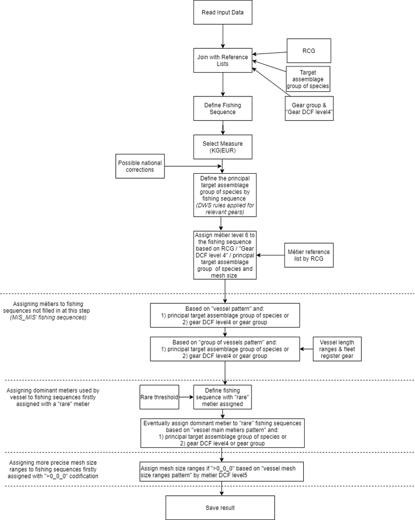

# Annex: Getting the code from GitHub

There are several ways to get the code from GitHub, three different ways are described here:

**Download zip-file directly from GitHub**

1. On the GitHub link: https://github.com/ices-eg/RCGs there is a green button called “Code”. If clicking on that there is a possibility to download Zip. This will download all content of RCG ISSG’s at GitHub.

[figure not shown]

2. Unzip the file at your computer. Under the “Metiers” -> “Scripts” folders, you can find the script_metiers.R file. Under the “Functions” folder the functions that the script reads are located. In the beginning of the script, make sure that it points to the Functions folder to read the functions.
3. To open the project from your computer under the “Metiers” folder you should run “Metiers.Rproj”. Then the path to all functions will be valid.

[figure not shown]

**Using GitHub Desktop**

1. Download GitHub Desktop here: https://desktop.github.com/
2. Define a folder where a copy of the GitHub content should be copied to
3. Set up the connection between GitHub RCGs url: https://github.com/ices-eg/RCGs and the folder on your computer.

**Using Git for Windows**

1. Install Git for Windows. You can download git from here https://git-scm.com/download/win. During the installation process you don’t have to change any options.
2. Once you have git installed you can start your RStudio. In the top right corner there is a button called “Project”. You should click it and select New Project.

[figure not shown]

3. A new window will show up. On that window select “Version Control”. Next select “Git”. In the next window you should enter the repository URL which is https://github.com/ices-eg/RCGs.git Note that RStudio for Windows prefers for Git to be installed below C:/Program Files and this appears to be the default. This implies, for example, that the Git executable on Windows system should be found at C:/Program Files/Git/bin/git.exe. In case when Git was installed in another directory you should select Tools -> Global options -> Git/SVN, and specify a path to the Git executable on your computer:

[figure not shown]

4. In the field “Create project as a subdirectory of” you can choose the directory on your hard disk where you want this project to be downloaded. And then click “Create project”. After a while RStudio will download (clone) the repository from github to your disk. This repository contains data from many RCG sobgroups. The content for the metier assignment is in the “Metier” subfolder.

# Contact Information

| Contact person | E-mail | Contact Issue |
| --- | --- | --- |
| Josefine Egekvist | jsv@aqua.dtu.dk | Questions regarding code lists |
| Sébastien Demaneche | Sebastien.Demaneche@ifremer.fr | Questions regarding methods and code lists |
| Maciej Adamowicz | madamowicz@mir.gdynia.pl | Questions regarding the R-script |